# 39 Numeric approximations to definite integrals

## 39.2 Error estimate

The Riemann sum above is actually extremely inefficient in that it can take a large number of rectangles to produce an “accurate” approximation for a definite integral, even for nice functions. To see how much so, we can derive an estimate for the error in approximating the value using an arithmetic progression as the partition. Let’s assume that our function $f(x)$ is increasing, so that the right sum gives an upper estimate and the left sum a lower estimate, so the error in any Riemann sum estimate will be smaller than the distance between these two values:

$$\begin{align*}
\text{error}
&\leq \text{upper sum} - \text{lower sum}\\
&=
\left(f(x_1) \cdot (x_{1} - x_0) + f(x_2) \cdot (x_{2} - x_1) + \cdots \right.\\
&\quad + \left. f(x_{n-1})(x_{n-1} - x_{n-2}) + f(x_n) \cdot (x_n - x_{n-1})\right)\\
&\quad -
\left(f(x_0) \cdot (x_{1} - x_0) + f(x_1) \cdot (x_{2} - x_1) + \cdots \right.\\
&\quad + \left. f(x_{n-1})(x_n - x_{n-1}) \right)\\
&=
\left(f(x_1) \cdot \Delta + f(x_2) \cdot \Delta + \cdots + f(x_{n-1})\Delta + f(x_n) \cdot \Delta y\right)\\
&\quad -
\left(f(x_0) \cdot \Delta + f(x_1) \cdot \Delta + \cdots + f(x_{n-1})\Delta\right) \\
&= \left(\left[f(x_1) + f(x_2) + \cdots + f(x_n)\right] - \left[f(x_0) + \cdots + f(x_{n-1})\right]\right) \cdot \Delta \\
&= \left(f(b) - f(a)\right) \cdot \frac{b-a}{n}.
\end{align*}$$

We see the error goes to $0$ at a rate of $1/n$ with the constant depending on $b-a$ and the function $f$. In general, a similar bound holds when $f$ is not monotonic.

### 39.2.1 The trapezoid rule

There are other ways to approximate the integral that use fewer points in the partition. Riemann sums approximate the definite integral over each “piece” of the partition—$\int_{x_{i-1}}^{x_i} f(x) dx$—using a rectangle. Other geometric shapes are possible.

The *trapezoid* rule uses a trapezoid formed to approximate this area, namely the one formed by $(x_{i-1}, 0)$, $(x_{i-1}, f(x_{i-1}))$, $(x_i, f(x_i))$, and $(x_i, 0)$ with area

$$\frac{1}{2} \left(f(x_{i-1}) + f(x_i) \right) \cdot (x_i - x_{i-1}).$$

If we use an equally spaced partition ($\Delta=(b-a)/n$) and add all the $n$ terms, we get single contributions from the endpoints and double from the others giving

$$A \approx (\frac{f(x_0)}{2} + \frac{f(x_n)}{2})\Delta + \sum_{i=1}^{n-1} f(x_i) \Delta/$$

In a later section, we will see that the error in using trapezoids to estimate the area is bounded, for some constant $K$:

$$\text{error} \leq \frac{K (b-a)^3}{12n^2}.$$

The $n^2$ means *roughly* that the error in the estimate using a Riemann sum with $n$ terms is similar to the error in the estimate using the trapezoid rule with $\sqrt{n}$ terms.[^1]

##### Example

Consider the integral

$$\int_0^2 x e^{-x} dx = 1 - 3 e^{-2} = 0.59399415\cdots$$

For comparison sake, we define the exact answer as a constant:

```julia
A = 1 - 3 * exp(-2)
```

```
0.5939941502901619
```

The error of a Riemann sum with $n=10^4$ is then:

```julia
a, b = 0, 2
f(x) = x * exp(-x)
riemann(f, a, b, 10^4; method="right") - A
```

```
2.7063272193594834e-5
```

and this is comparable to the error of the trapezoid method with $n=10^2$:

```julia
riemann(f, a, b, 10^2; method="trapezoid") - A
```

```
-3.7843872858767114e-5
```

### 39.2.2 Simpson’s rule

[Simpson’s](http://tinyurl.com/7b9pmu) rule is one, where instead of approximating the area with rectangles that go through some $c_i$ in $[x_{i-1}, x_i]$ instead the function is approximated by the quadratic polynomial going through $x_{i-1}$, $(x_i + x_{i-1})/2$, and $x_i$ and the exact area under that polynomial is used in the approximation. The explicit formula for a single partition is[^2]

$$\int_{x_{i-1}}^{x_i} f(x) dx \approx \frac{x_i - x_{i-1}}{6}\left(f(x_{i-1}) + 4f(\frac{x_{i-1} + x_i}{2}) + f(x_i)\right)$$

The error in this approximation can be shown to be

$$\text{error} \leq \frac{(b-a)^5}{180n^4} \text{max}_{\xi \text{ in } [a,b]} \lvert f^{(4)}(\xi) \rvert.$$

That is, the error is like $1/n^4$ with constants depending on the length of the interval, $(b-a)^5$, and the maximum value of the fourth derivative over $[a,b]$. This is significant, the error in $10$ steps of Simpson’s rule is on the scale of the error of $10,000$ steps of the Riemann sum for well-behaved functions.

**NoteNote**

The Wikipedia article mentions that Kepler used a similar formula $100$ years prior to Simpson, or about $200$ years before Riemann published his work. Again, the value in Riemann’s work is not the computation of the answer, but the framework it provides in determining if a function is Riemann integrable or not.

##### Example

Continuing the previous example, the accuracy of Simpson’s rule with $10$ steps is comparable to that of a Riemann sum with $10^4$ steps:

```julia
riemann(f, a, b, 10; method="simpsons") - A
```

```
-1.5884464277249322e-6
```

## 39.3 Gauss quadrature

There are function types where the above approximations are actually exact:

- Riemann sums are exact for *constant* functions (polynomials with order $0$)
- The trapezoid method is exact for *linear* functions (polynomials with order $1$)
- Simpson’s rule is exact for *quadratic* functions (polynomials with degree $2$)

This pattern could be extended by taking more intermediate points. In fact an entire family of similar approximations using $n$ points can be made exact for any polynomial of degree $n-1$ or lower. However, by choosing points judiciously—not necessarily evenly spaced out and not necessarily including the end points—$n$ points can be exact for polynomials of degree higher than $n$. (Simpson’ rule actually being exact for *cubic* polynomials is something that hints at this.)

The formulas for an approximation to the integral $\int_{-1}^1 f(x) dx$ discussed so far can be written as:

$$\begin{align*}
S &= f(x_1) \Delta_1 + f(x_2) \Delta_2 + \cdots + f(x_n) \Delta_n\\
&= w_1 f(x_1) + w_2 f(x_2) + \cdots + w_n f(x_n)\\
&= \sum_{i=1}^n w_i f(x_i).
\end{align*}$$

The $w$s are “weights” and the $x$s are nodes. Restricting to the interval $[-1,1]$ presents no loss in generality.

A [Gaussian](http://en.wikipedia.org/wiki/Gaussian_quadrature) *quadrature rule* is a set of weights and nodes for $i=1, \dots n$ for which the sum is *exact* for any $f$ which is a polynomial of degree $2n-1$ or less. Such choices then also approximate well the integrals of functions which are not polynomials of degree $2n-1$ or less, provided $f$ can be well approximated by a polynomial over $[-1,1]$. (Which is the case for the “nice” functions we encounter, though not for highly oscillatory functions.) More details are discussed in the section on *orthogonal polynomials* and some examples are given in the questions.

### 39.3.1 The quadgk function

In `Julia` a modification of the Gauss quadrature rule is implemented in the `quadgk` function (from the `QuadGK` package) to give numeric approximations to integrals. The `quadgk` function also has the familiar interface `action(function, arguments...)`. Unlike our `riemann` function, there is no `n` specified, as the number of steps is *adaptively* determined. (There is more partitioning occurring where the function is changing rapidly.) Instead, the algorithm outputs an estimate on the possible error along with the answer. Instead of $n$, some trickier problems require a specification of an error threshold.

To use the function to integrate `f` over an interval `[a,b]` we have:

```julia
f(x) = x * log(x)
quadgk(f, 0, 2)
```

```
(0.38629436103070175, 4.856575112145755e-9)
```

As mentioned, there are two values returned: an approximate answer, and an error estimate. In this example we see that the value of $0.3862943610307017$ is accurate to within $10^{-9}$. (The actual answer is $-1 + 2\cdot \log(2)$ and the error is only $10^{-11}$. The reported error is an estimated upper bound, and may be conservative, as with this problem.) Our previous answer using $50,000$ right-Riemann sums was $0.38632208884775737$ and is only accurate to $10^{-5}$. By contrast, this method uses just $256$ function evaluations in the above problem.

The method should be exact for polynomial functions:

```julia
f(x) = x^5 - x + 1
quadgk(f, -2, 2)
```

```
(3.9999999999999973, 1.3322676295501878e-15)
```

The error term is $0$, the answer is $4$ up to the last unit of precision (1 ulp), so any error is only in floating point approximations.

For the numeric approximation of a definite integral, the `quadgk` function should be preferred over the other methods previously discussed.

Here are some sample integrals computed with `quadgk`:

$$\int_0^\pi \sin(x) dx$$

```julia
quadgk(sin, 0, pi)
```

```
(2.0000000000000004, 1.7901236049056024e-12)
```

(Again, the actual answer is off only in the last digit, the error estimate is an upper bound.)

$$\int_0^5 e^x dx$$

```julia
quadgk(exp, 0, 5)
```

```
(147.41315910257657, 2.6594506152832764e-8)
```

$$\int_0^2 x^x dx$$

```julia
u(x) = x^x
quadgk(u, 0, 2)
```

```
(2.8338767448900546, 1.948175154531384e-8)
```

The function $x^x$ is not continuous at $0$, but can be defined to be so. In this case, the numeric definition of `0^0` matches the limit, so no discussion of redefining the function is necessary, as was done earlier with the function $x\cdot \log(x)$.

In fact, the specified endpoints to `quadgk` are *never* evaluated, so such concerns are not needed. (Which can be exploited when integrals involving functions with vertical asymptotes are discussed.) This is why the first example—which integrated `x*log(x)`—did not return `NaN` but rather an estimate for the integral.

#### Dropping the error term

When composing the answer with other functions it may be desirable to drop the error in the answer, we discuss three styles that can be used for this. The first is to just name the two returned values:

```julia
A, err = quadgk(cos, 0, pi/4)
A
```

```
0.7071067811865475
```

The second is to ask for just the first component of the returned value:

```julia
A = first(quadgk(tan, 0, pi/4))
```

```
0.3465735902799726
```

Finally, direct indexing can be applied, as with

```julia
quadgk(tan, 0, pi/4)[1]
```

```
0.3465735902799726
```

Though we try to avoid this style in favor of being more explicit when that is convenient.

##### Example

In probability theory, a *univariate density* is a function, $f(x)$ such that $f(x) \geq 0$ and $\int_a^b f(x) dx = 1$, where $a$ and $b$ are the range of the distribution.

The [Von Mises](http://en.wikipedia.org/wiki/Von_Mises_distribution) distribution, takes the form

$$k(x) = C \cdot \exp(\cos(x)), \quad -\pi \leq x \leq \pi.$$

Compute $C$ (numerically).

The fact that $1 = \int_{-\pi}^\pi C \cdot \exp(\cos(x)) dx = C \int_{-\pi}^\pi \exp(\cos(x)) dx$ implies that $C$ is the reciprocal of the definite integral:

```julia
k(x) = exp(cos(x))
A, err = quadgk(k, -pi, pi)
```

```
(7.954926521012919, 3.9023298370466364e-8)
```

So

```julia
C = 1/A
k₁(x) = C * exp(cos(x))
```

```
k₁ (generic function with 1 method)
```

The *cumulative distribution function* for $k(x)$ is $K(x) = \int_{-\pi}^x k(u) du$, $-\pi \leq x \leq \pi$. We just showed that $K(\pi) = 1$ and it is trivial that $K(-\pi) = 0$. The quantiles of the distribution are the values $q_1$, $q_2$, and $q_3$ for which $K(q_i) = i/4$. Can we find these?

First we define a function, that computes $K(x)$. We only need the first of the two answers given by `quadgk`.

```julia
K(x) = first(quadgk(k₁, -pi, x))
```

```
K (generic function with 1 method)
```

The question asks us to solve $K(x) = 0.25$, $K(x) = 0.5$ and $K(x) = 0.75$. The `Roots` package can be used for such work, in particular `find_zero`. We will use a bracketing method, as clearly $K(x)$ is increasing, as $k(u)$ is positive, so we can just bracket our answer with $-\pi$ and $\pi$. (We solve $K(x) - p = 0$, so $K(\pi) - p > 0$ and $K(-\pi)-p < 0$.). We could do this with a comprehension, but for variety use broadcasting with `solve` below.

```julia
Z = ZeroProblem((x,p) -> K(x) - p, (-pi, pi))
solve.(Z, (1/4, 1/2, 3/4))
```

```
(-0.8097673745015915, 0.0, 0.8097673745016285)
```

The middle one is clearly $0$. This distribution is symmetric about $0$, so half the area is to the right of $0$ and half to the left, so clearly when $p=0.5$, $x$ is $0$. The other two show that the area to the left of $-0.809767$ is equal to the area to the right of $0.809767$ and equal to $0.25$.

#### Visualizing the nodes chosen by `quadgk`

To visualize the choice of nodes by the algorithm, In Figure 39.2 the nodes chosen are shown for $f(x)=\sin(x)$ over $[0,\pi]$. Relatively few nodes used to get a high-precision estimate.

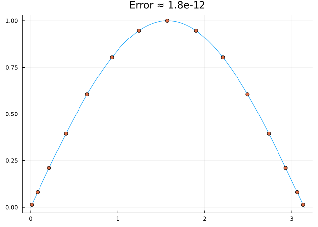

Figure 39.2: The nodes chosen by `quadgk` for $f(x) = \sin(x)$ over $[0, \pi]$

For a more oscillatory function, more nodes are chosen, as seen in Figure 39.3.

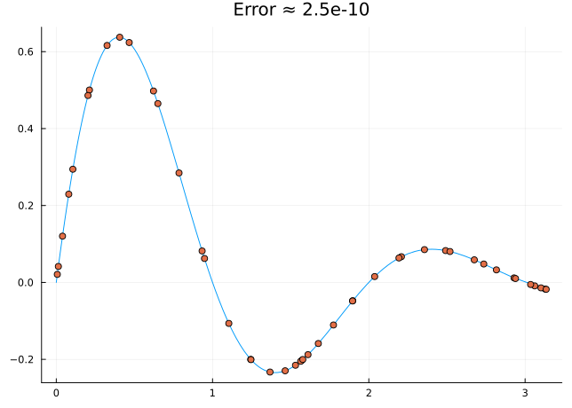

In both Figure 39.2 and Figure 39.3 it can be verified that no node is one of the endpoints.

##### Example: Gauss nodes

The `QuadGK.gauss(n)` function returns a pair of $n$ quadrature points and weights to integrate a function over the interval $(-1,1)$, with an option to use a different interval $(a,b)$. For a given $n$, these values exactly integrate any polynomial of degree $2n-1$ or less. In this example, these $5$ points produce an answer accurate already to the $5$th decimal point.

```julia
xs, ws = QuadGK.gauss(5)
```

```
([-0.906179845938664, -0.5384693101056831, 0.0, 0.5384693101056831, 0.906179845938664], [0.2369268850561892, 0.4786286704993663, 0.5688888888888887, 0.4786286704993663, 0.2369268850561892])
```

```julia
f(x) = exp(cos(x))
sum(w * f(x) for (x, w) in zip(xs, ws))
```

```
4.68315881456892
```

The pattern to integrate can be expressed in other ways, but using the `zip` function to iterate over the `xs` and `ws` as pairs of values is pretty direct.

## 39.4 Questions

###### Question

For the function $f(x) = \sin(\pi x)$, estimate the integral for $-1$ to $1$ using a left-Riemann sum with the partition $-1 < -1/2 < 0 < 1/2 < 1$.

###### Question

For the right Riemann sum approximating $\int_0^{10} e^x dx$ with $n=100$ subintervals, what would be a good estimate for the error?

\((10 - 0) \cdot e^{10} / 100^4\)

\((10 - 0)/100 \cdot (e^{10} - e^{0})\)

\(10/100\)

###### Question

Use `quadgk` to find the following definite integral:

$$\int_1^4 x^x dx .$$

###### Question

Use `quadgk` to find the following definite integral:

$$\int_0^3 e^{-x^2} dx .$$

###### Question

Use `quadgk` to find the following definite integral:

$$\int_0^{9/10} \tan(u \frac{\pi}{2}) du.$$

###### Question

Use `quadgk` to find the following definite integral:

$$\int_{-1/2}^{1/2} \frac{1}{\sqrt{1 - x^2}} dx$$

###### Question

Let $A=1.98$ and $B=1.135$ and

$$f(x) = \frac{1 - e^{-Ax}}{B\sqrt{\pi}x} e^{-x^2}.$$

Find $\int_0^1 f(x) dx$

###### Question

A bound for the complementary error function ( positive function) is

$$\text{erfc}(x) \leq \frac{1}{2}e^{-2x^2} + \frac{1}{2}e^{-x^2} \leq e^{-x^2}
\quad x \geq 0.$$

Let $f(x)$ be the first bound, $g(x)$ the second. Assuming this is true, confirm numerically using `quadgk` that

$$\int_0^3 f(x) dx \leq \int_0^3 g(x) dx$$

The value of $\int_0^3 f(x) dx$ is

The value of $\int_0^3 g(x) dx$ is

###### Question

$$f(x) = \frac{1}{\sqrt{ x^4 + 10x^2 - 60x + 100}}.$$

When $n=5$ what is the area of the Riemann sum?

When $n=50$ what is the area of the Riemann sum?

Using `quadgk` what is the area under the curve?

###### Question

Gauss nodes for approximating the integral $\int_{-1}^1 f(x) dx$ for $n=4$ are:

```julia
ns = [-0.861136, -0.339981, 0.339981, 0.861136]
```

```
4-element Vector{Float64}:
 -0.861136
 -0.339981
  0.339981
  0.861136
```

The corresponding weights are

```julia
wts = [0.347855, 0.652145, 0.652145, 0.347855]
```

```
4-element Vector{Float64}:
 0.347855
 0.652145
 0.652145
 0.347855
```

Use these to estimate the integral $\int_{-1}^1 \cos(\pi/2 \cdot x)dx$ with $w_1f(x_1) + w_2 f(x_2) + w_3 f(x_3) + w_4 f(x_4)$.

The actual answer is $4/\pi$. How far off is the approximation based on 4 points?

around \(10^{-1}\)

around \(10^{-2}\)

around \(10^{-4}\)

around \(10^{-6}\)

around \(10^{-8}\)

###### Question

Using the Gauss nodes and weights from the previous question, estimate the integral of $f(x) = e^x$ over $[-1, 1]$. The value is:

[^1]: There are functions where the trapezoid method has much faster convergence, even exponential. (cf. [this article](https://people.maths.ox.ac.uk/trefethen/sirev56-3_385.pdf) and [these notes](https://math.mit.edu/~stevenj/trap-iap-2011.pdf) for some background.)
[^2]: The `riemann` function sums this expression, but this approach is inefficient computationally. Alternative formulations would be suggested.